# Chapter 4 HW

Bryan Li

2/3/2019

### 20)

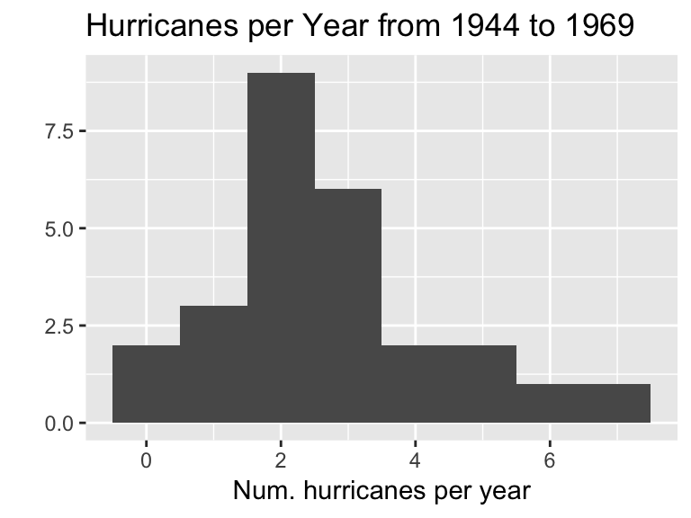

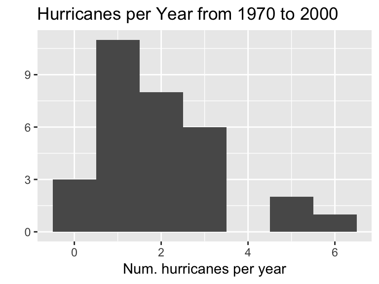

The hurricanes from 1944 to 1969 tend to center around 2-3, and is mostly symmetrical with only a bit of a right skew. The hurricanes from 1970 to 2000 tend to center around 1-2 and skews more heavily towards the right.

### 22)

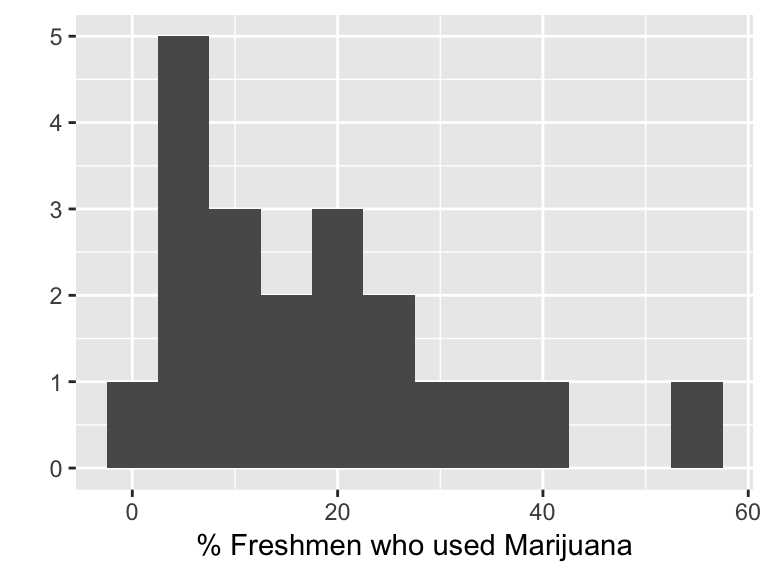

### 38)

#### a/b)

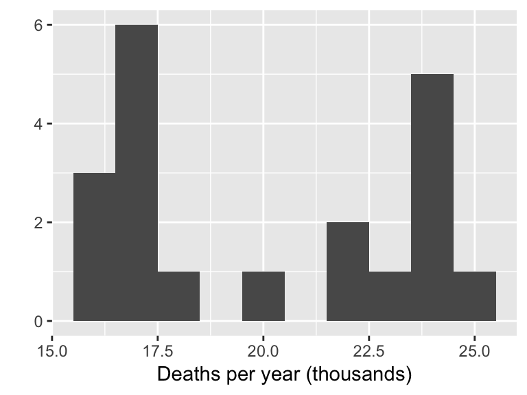

[figure not shown]

#### c)

Deaths from drunk driving have been steadily falling over time. There are also two modes, which implies that there was something that changed in between 1990 and 1993 that caused a relatively significant drop in the amount of drunk driving-related deaths.

### 39)

#### a)

The huge skew towards the right makes it hard to summarize center and spread as it is hard to assess the data and its center and spread.

#### b)

The data can be re-expressed by using a logarithmic or fractional exponent (e.g., square root) function.

### 41)

#### a)

Re-expression with logarithms is better as it is closer to a symmetrical shape.

#### b)

In the square root re-expression, 50 indicates assets of 2500 as it is squared.

#### c)

In the logarithmic re-expression, the value 3 indicates assets of 1000.